# Compare OLS and LMM in GWAS simulations

Andrey Ziyatdinov

2017-01-13

# 1 Data simulation

## 1.2 LMM

LMM architecture

- Two random effects: genetic and residual.
- The variance exmplained (that is the heritability in this case) varied among 0.1, 0.3, 0.6 and 0.9

# 2 Under the null

## 2.1 Variance of the effect

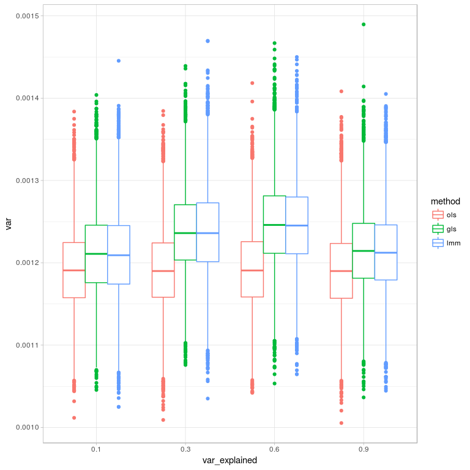

Observations:

- The effect variance for OLS is remained constant over different values of `var_explained` parameter. That what we expected: samples pooled for OLS are independent and have zero genetic variance.
- The effect variance for LMM depend on `var_explained` values, but this law is not smooth. We might suspect that the law is related more to the variance-covariance structure that to the values of variance components (sigmas).

## 2.2 Magnitude of the effect

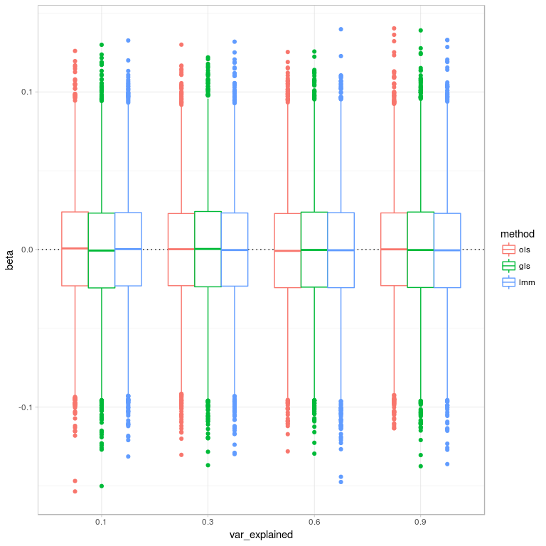

## 2.3 Distribution of scores

$Z^2$ corresponds to the chi-squared distribution.

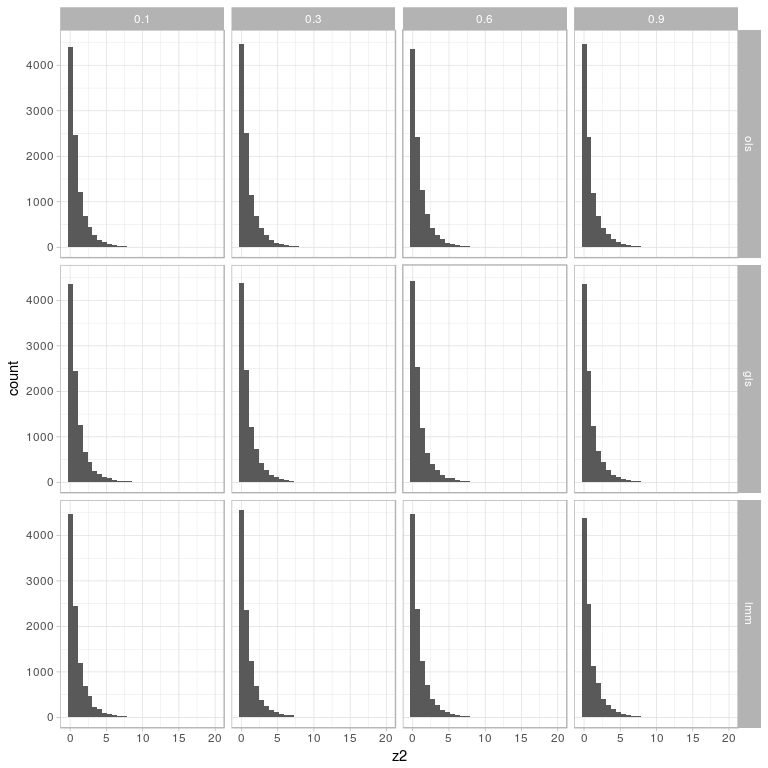

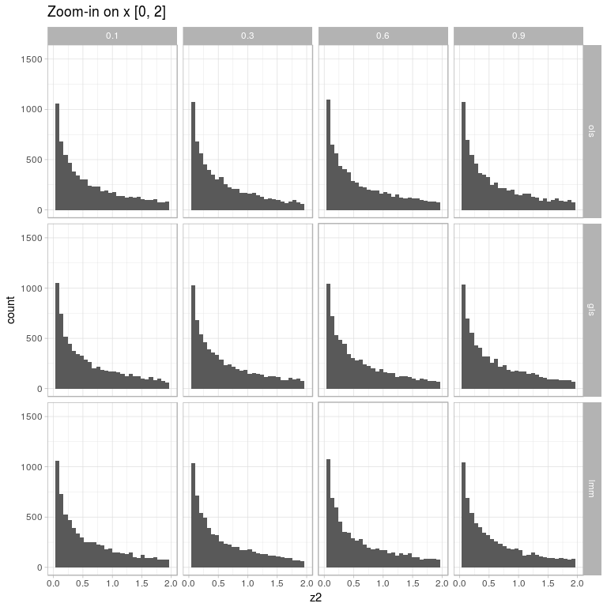

## 2.4 Distribution of p-values

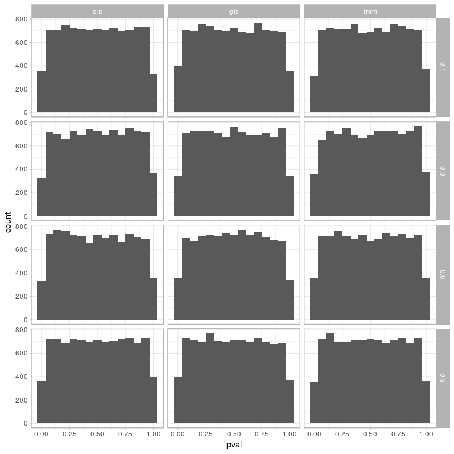

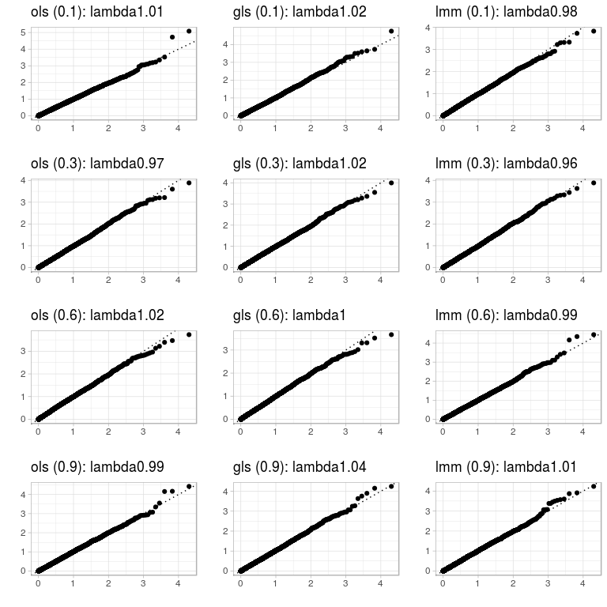

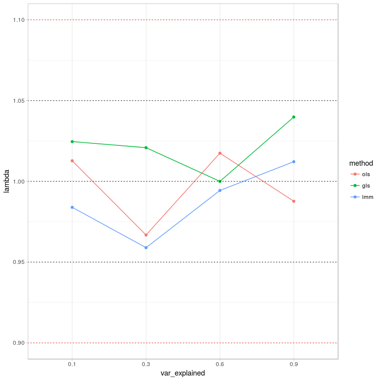

# 3 Under the alternative

Here we repeat the procedure from the previous Section udner the alternative.

We’d like to confirm:

- that the law for LMM is the same for the effect variance *vs.* `var_explained` values
- the effect variance of OLS is the lowest in comparison with GLS and LMM
  - the power for the Walt test is to be the best for OLS

## 3.1 Variance of the effect

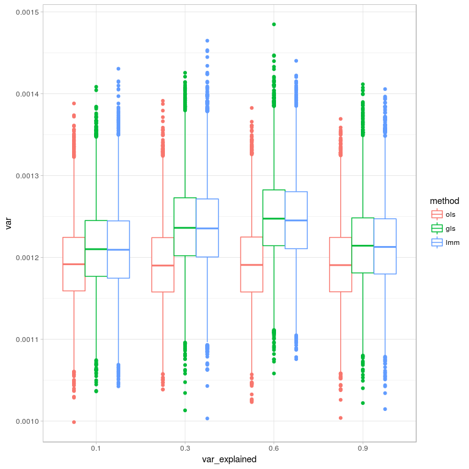

## 3.2 Magnitude of the effect

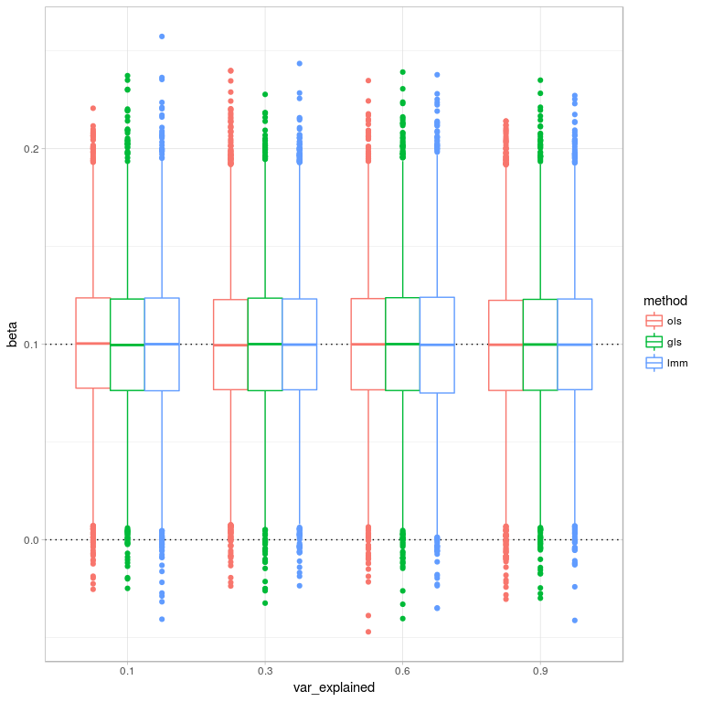

## 3.3 Distribution of p-values

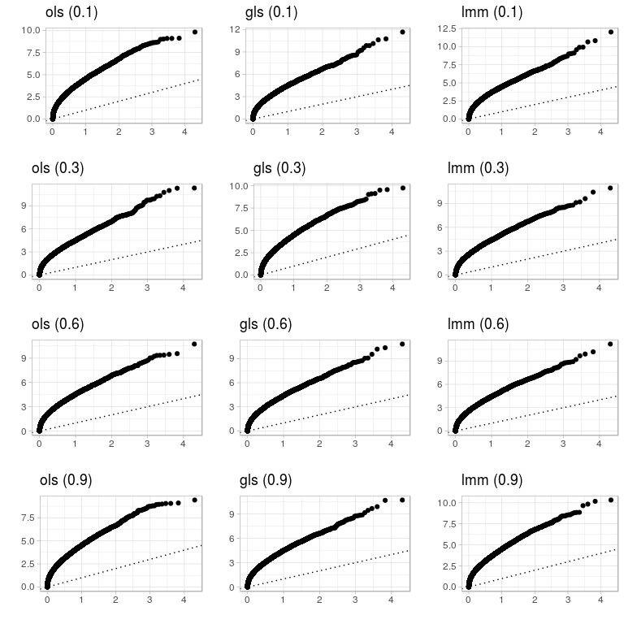

## 3.4 Power

Threshold: 0.05.

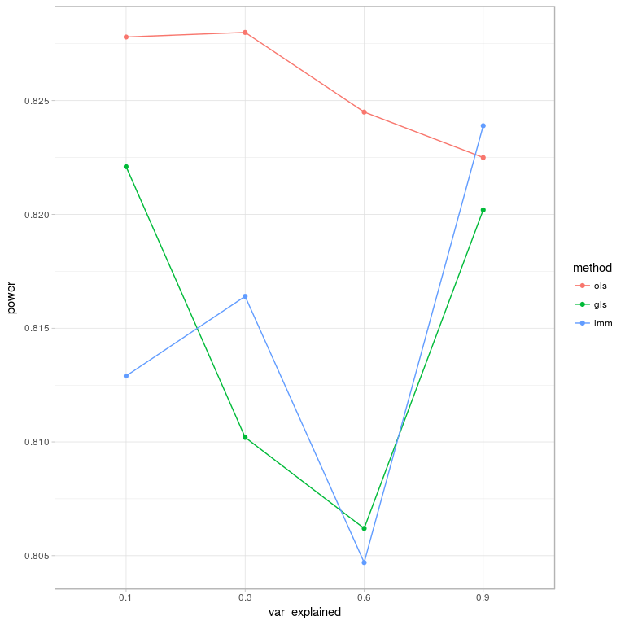

# 4 Explanation of the tendencies

What tendencies have we observed on the previous figures?

1. The effect variance is the lowest for OLS comparing with GLS and LMM.
2. The effect variance somehow depend on the heritability or variance explained by genes.

Remeber the formulas:

| Study | var(y) | var(g) | var(beta) | Approximation | Upper Bound |  |
| --- | --- | --- | --- | --- | --- | --- |
| (Pooled) Independent | $\sigma_g^2 I + \sigma_r^2 I = \sigma_r^{*2} I$ | $2pq I$ | $\frac{\hat{\sigma}_r^{*2}}{g_c^T g_c}$ | $\frac{\hat{\sigma}_r^{*2}}{2pq N} \approx \frac{1}{2pq N}$ |  |  |
| Common random effect | $\sigma_f^2 F + \sigma_r^2 I$ | $2pq I$ | $\frac{1}{g_c^T \hat{V}^{-1} g_c}$ | $\frac{1}{2pq \mbox { } trace(\hat{V}^{-1})}$ | $\frac{\hat{\sigma}_g^2 + \hat{\sigma}_r^2}{2pq N} \approx \frac{1}{2pq N}$ |  |
| Genetic random effect | $\sigma_g^2 K + \sigma_r^2 I$ | $2pq K$ | $\frac{1}{g_c^T \hat{V}^{-1} g_c}$ | $\frac{1}{2pq \mbox { } trace(\hat{V}^{-1}K)}$ | $\frac{(\sum{\lambda^{-1}_K}/N) \hat{\sigma}_g^2 + \hat{\sigma}_r^2}{2pq N}$ |  |

Notes

- In the current status of this report, we present experiments only for the situation given on the 1st and 3rd rows of the table.
  - It would be interesting to conduct an experiment for the 2nd row, i.e. “Common random effect”.
  - Results expected for “Common random effect” will be opposite to “Genetic random effect”, as suggest both, derivations in the table above and table in the further section 4.2.

What can we conclude from the table with formulas given above?

- The factor of relative difference between OLS (row 1) and LMM (both row 2 Common and row 3 Genetic random effect) is equal to the trace value divided by $N$.

## 4.1 LMM: genetic random effect

The effect variance estimated by LMM varies with `var_explained` parameter. See Figures in Sections 2.1 (under the null) and 3.1 (under the alternative).

| var_explained | trace_transform | trace_transform_by_n |
| --- | --- | --- |
| 0.1 | 1853.311 | 0.9266553 |
| 0.3 | 1694.623 | 0.8473113 |
| 0.6 | 1650.674 | 0.8253369 |
| 0.9 | 1828.003 | 0.9140013 |

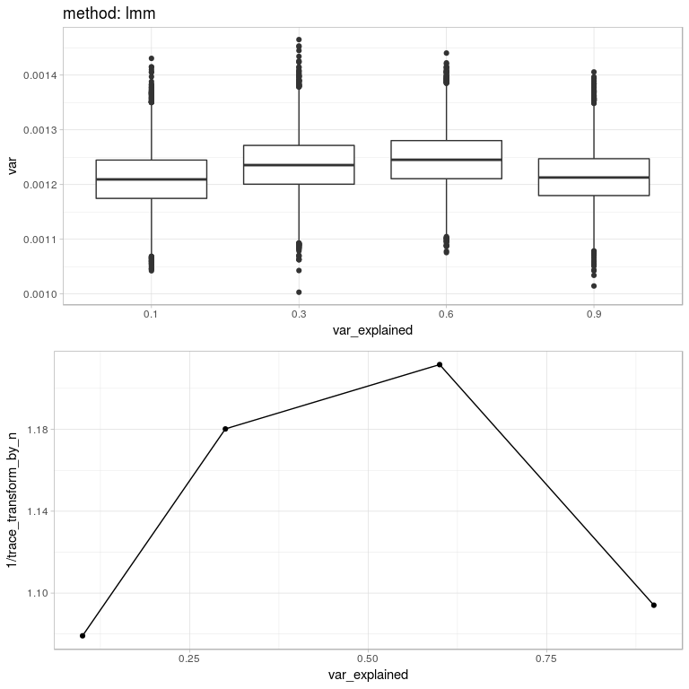

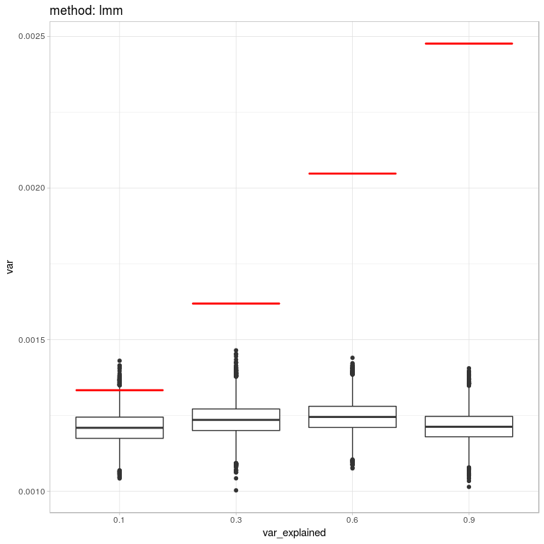

## 4.2 LMM: common variance (family) effect

The figure in Section [3.2.2](https://hemostat.github.io/Public/gxefam/reports/05-gxefam-formulae/05-gxefam-formulae.html#common-variance-effect) from the previous report showed how the effect variance depended on the `var_explained` parameter.

This dependency is smooth, that can be seen ether on the figure in the previous report or on the table given below.

| var_explained | trace_transform | trace_transform_by_n |
| --- | --- | --- |
| 0.3 | 2467.532 | 1.233766 |
| 0.6 | 4117.647 | 2.058824 |
| 0.9 | 16086.957 | 8.043478 |

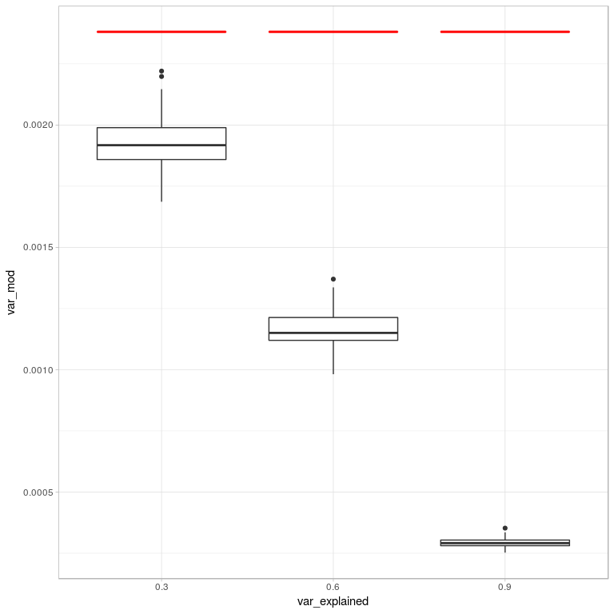

## 4.3 Conclusions

- Empirically, we observed that the factor `trace_transform_by_n` is
  - less than 1 for Genetic random effect (that means pooling samples increases the effect variance – a bad thing)
  - greater than 1 for Common random effect (that means pooling samples decreases the effect variance – a good thing)
- In the Common random effect Scenario, using the upper bound for the exact solution for effect variance, we have shown that pooling samples always decreases the effect variance and improves the power – a good thing.
- The discrapency between the exact computation of effect variance and its upper bound is increasing when the heritability is increasing.
  - With the heritability is increasing, approximation using the upper bound of the effect variance is getting worse.